# PracticalMachineLearning

Subhash Mantha

Tuesday, July 22, 2014

## Summary:

This exercise is to predict the way an exercise is classified based on the bodily movements, and positions. The data for this exercise is obtained from the work done by Ugulino et al. (Ugulino, W.; Cardador, D.; Vega, K.; Velloso, E.; Milidiu, R.; Fuks, H. Wearable Computing: Accelerometers’ Data Classification of Body Postures and Movements Read more: http://groupware.les.inf.puc-rio.br/har#weight_lifting_exercises#ixzz38KSCiFFa) . The exercise described is a barbell lift. The outcomes of the exercise are categorized into five different groups A through E. A is the correct way of doing the exercise whereas categories B through E are with atleast one type of mistake either in movement or position. The data is collected via accelerometers connected to the arm, forearm and belt. The dumbbell has a sensor on it which tracks its position in the three dimensional space. Principal component Analysis and Random Forest methods have been used in building the model.Out of sample error from the cross validaation set is less than 3%

## Analysis:

Libraries have been used as part of the analysis are *randomForest*,*caret* and *e1071*. As first step data is cleansed of all the derived variables. Other variables that have unusable values are also cleaned up. Principal Component analysis is used to identify the variables that are used in the final model. pml-training.csv file is split into two dataframes with a 60/40 split ratio. 60 % of the data is used to train the model and remaining 40 % is used for cross validating the model.

```r
set.seed(2343)
library(randomForest)
library("e1071", lib.loc="C:/Program Files/R/R-3.0.3/library")
library(caret)
traindata<-read.csv("./pml-training.csv", header=TRUE, as.is = TRUE, stringsAsFactors = FALSE, sep=',', na.strings=c('NA','','#DIV/0!'))
testdata<-read.csv("./pml-testing.csv", header=TRUE, as.is = TRUE, stringsAsFactors = FALSE, sep=',', na.strings=c('NA','','#DIV/0!'))
collist<-colnames(traindata)

collistr<-grep("avg_", collist, ignore.case = TRUE, perl = FALSE, value = TRUE,
     fixed = FALSE, useBytes = FALSE, invert = FALSE)
collist<-collist[!collist %in% collistr]

collistr<-grep("stddev_", collist, ignore.case = TRUE, perl = FALSE, value = TRUE,
     fixed = FALSE, useBytes = FALSE, invert = FALSE)
collist<-collist[!collist %in% collistr]

collistr<-grep("skewness_", collist, ignore.case = TRUE, perl = FALSE, value = TRUE,
     fixed = FALSE, useBytes = FALSE, invert = FALSE)
collist<-collist[!collist %in% collistr]

collistr<-grep("var_", collist, ignore.case = TRUE, perl = FALSE, value = TRUE,
     fixed = FALSE, useBytes = FALSE, invert = FALSE)
collist<-collist[!collist %in% collistr]

collistr<-grep("min_", collist, ignore.case = TRUE, perl = FALSE, value = TRUE,
     fixed = FALSE, useBytes = FALSE, invert = FALSE)
collist<-collist[!collist %in% collistr]

collistr<-grep("max_", collist, ignore.case = TRUE, perl = FALSE, value = TRUE,
     fixed = FALSE, useBytes = FALSE, invert = FALSE)
collist<-collist[!collist %in% collistr]

collistr<-grep("total_", collist, ignore.case = TRUE, perl = FALSE, value = TRUE,
     fixed = FALSE, useBytes = FALSE, invert = FALSE)
collist<-collist[!collist %in% collistr]

collistr<-grep("kurtosis_", collist, ignore.case = TRUE, perl = FALSE, value = TRUE,
     fixed = FALSE, useBytes = FALSE, invert = FALSE)
collist<-collist[!collist %in% collistr]

collistr<-grep("amplitude_", collist, ignore.case = TRUE, perl = FALSE, value = TRUE,
     fixed = FALSE, useBytes = FALSE, invert = FALSE)
collist<-collist[!collist %in% collistr]

dataforanaltrain<-traindata[,collist]

intrain<-createDataPartition(y=dataforanaltrain$classe,p=0.6,list=FALSE)
Train<-dataforanaltrain[intrain,]
Test<-dataforanaltrain[-intrain,]

collistn<-collist[!collist %in% c("classe","X","user_name","raw_timestamp_part_1","raw_timestamp_part_2","cvtd_timestamp","new_window" ,        "num_window")]
```

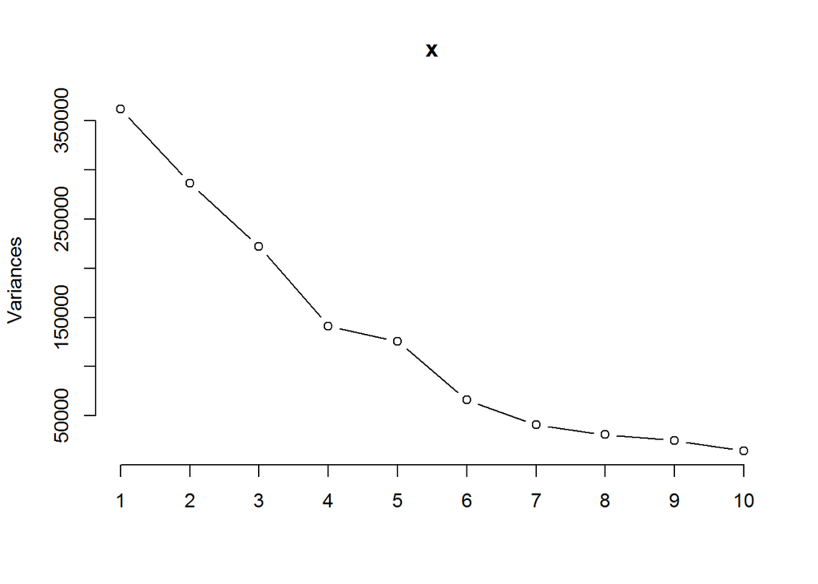

```r
x<-prcomp(Train[,collistn])
screeplot(x, type="lines")
```

```r
x$sdev^2
```

```
##  [1] 3.617e+05 2.863e+05 2.222e+05 1.411e+05 1.259e+05 6.610e+04 4.070e+04
##  [8] 3.064e+04 2.487e+04 1.411e+04 9.344e+03 8.102e+03 5.884e+03 4.727e+03
## [15] 3.903e+03 3.232e+03 2.852e+03 2.483e+03 2.379e+03 1.726e+03 1.413e+03
## [22] 1.248e+03 1.089e+03 9.240e+02 6.427e+02 5.189e+02 4.552e+02 4.366e+02
## [29] 2.914e+02 2.304e+02 1.922e+02 9.536e+01 5.687e+01 3.571e+01 1.407e+01
## [36] 1.156e+01 4.598e+00 3.854e+00 2.578e-01 1.718e-01 1.315e-01 1.054e-01
## [43] 9.935e-02 5.811e-02 3.823e-02 3.464e-02 1.079e-02 1.342e-03
```

```r
Train$classe <- as.factor(Train$classe)
```

```r
set1 <- collistn[1:4]
set2 <- collistn[1:12]
set3 <- collistn[1:33]

collistn<-c(set1,"classe")
modFit1 <- train(classe ~., method="rf", data=Train[,collistn], trControl=trainControl(method='cv'), number=5, allowParallel=TRUE )
testingPred1 <- predict(modFit1, Test[,set1])
table(testingPred1==Test$classe)
```

```
##
## FALSE  TRUE
##   848  6998
```

```r
collistn<-c(set2,"classe")
modFit2 <- train(classe ~., method="rf", data=Train[,collistn], trControl=trainControl(method='cv'), number=5, allowParallel=TRUE )
testingPred2 <- predict(modFit2, Test[,set2])
table(testingPred2==Test$classe)
```

```
##
## FALSE  TRUE
##   681  7165
```

```r
collistn<-c(set3,"classe")
modFit3 <- train(classe ~., method="rf", data=Train[,collistn], trControl=trainControl(method='cv'), number=5, allowParallel=TRUE )
testingPred3 <- predict(modFit3, Test[,set3])
table(testingPred3==Test$classe)
```

```
##
## FALSE  TRUE
##   145  7701
```

Random forest was used to build the models and the model results thus obtained is used to predict the results of the cross validation sets. Ten fold cross validation is performed during the tree selection. The results for the final model are shown below. The final model modFit3 is used for predicting the results of pml-testing.csv data.

```r
modFit3
```

[output not shown]

```r
testingPred <- predict(modFit3, testdata[,set3])
```